# bikeshare-explanatory slides

## Distribution of Ride Duration

Ride durations vary widely, from 60 seconds to 60,000 seconds. Plotted on a logarithmic scale, the distribution of Ride duration takes on a symmetric unimodal shape.

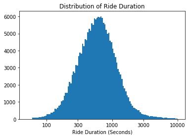

```python
log_bin_edges = np.arange(1.7, 4.0 + 0.02, 0.02)
plt.hist(np.log10(bikeshare_data['duration_sec']), bins=log_bin_edges)
locs, labels = plt.xticks()
ticks = [100, 300, 1000, 3000, 10000];
log_ticks = np.log10(ticks)
# print(log_ticks)
plt.xticks(log_ticks, ticks)
plt.xlabel('Ride Duration (Seconds)')
plt.title('Distribution of Ride Duration');
```

## Adapted Bar Chart: No. of Rides per Day vs. Day of Month (August)

It can be shown by the chart that there are greater number of rides during the weekdays (each peak of 5 days) compared to weekends.

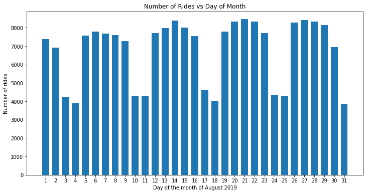

```python
plt.figure(figsize=(12, 6))
bin_edges = np.arange(0.5, 30.5 + 1.1, 1)
start_time_datetime = bikeshare_data['start_time'].sort_values(ascending=True)
start_time_datetime_day = start_time_datetime.apply(lambda x: x.day)
plt.hist(start_time_datetime_day, bins=bin_edges, rwidth=0.7)
plt.xticks(np.arange(1, 31 + 1, 1))
plt.xlabel('Day of the month of August 2019')
plt.ylabel('Number of rides')
plt.title('Number of Rides vs Day of Month');
```

## Boxplot: Rider Age

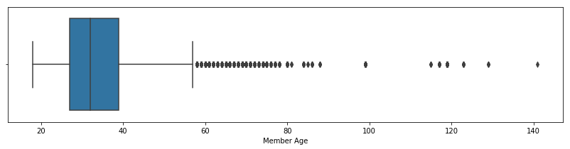

```python
plt.figure(figsize=(14, 3))
color = sb.color_palette()[0]
sb.boxplot(data=bikeshare_data, x='member_age')
plt.xlabel("Member Age");
```

## Customers vs Subscribers

Of the rides present in this dataset, there are much higher frequencies of subscribers compared to customers.

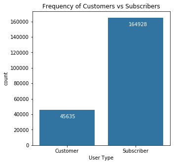

```python
plt.figure(figsize=(5, 5))
color = sb.color_palette()[0]
sb.countplot(data=bikeshare_data, x='user_type', color=color)
custCount = (bikeshare_data['user_type'] == 'Customer').sum()
subCount = (bikeshare_data['user_type'] == 'Subscriber').sum()
# print(custCount)
# print(subCount)
plt.rcParams['text.color'] = 'white';
plt.text(0-0.1, custCount - 10500, '{:.0f}'.format(custCount))
plt.text(1-0.1, subCount - 10500, '{:.0f}'.format(subCount))
plt.rcParams['text.color'] = 'black';
plt.xlabel('User Type')
plt.title('Frequency of Customers vs Subscribers');
```

## Ride Distance

With a logarithmic scale applied, the ride distance takes on a relatively symmetric shape. There is a jump of frequencies on 0 miles, because several users choose to dock at the same bike station from where they left their bikes.

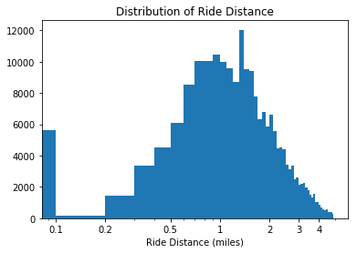

```python
bin_edges = np.arange(0, 5, 0.1)
plt.hist(data=bikeshare_data, x='route_distance', bins=bin_edges)
plt.xscale('log')
labels = np.arange(0, 2, 1)
plt.xticks([0.1, 0.2, 0.5, 1, 2, 3, 4], ['0.1', '0.2', '0.5', '1', '2', '3', '4'])
# plt.xticks(labels, labels);
plt.xlabel('Ride Distance (miles)')
plt.title('Distribution of Ride Distance');
```

## Average Ride Duration vs Day of Month (Aug)

It can be seen from the plot that users tend to ride for longer over the weekends (in blue) compared to weekdays (orange). This pattern seems to be kept relatively steady.

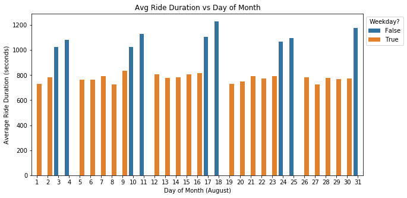

```python
plt.figure(figsize=(10, 5))
sb.barplot(data=bikeshare_data, x=bikeshare_data.start_time.dt.day, y='duration_sec', color=color, hue='start_is_weekday', palette=sb.color_palette(n_colors=2), ci=None)
plt.legend(title='Weekday?', bbox_to_anchor=(1, 1))
plt.xlabel('Day of Month (August)')
plt.ylabel('Average Ride Duration (seconds)')
plt.title('Avg Ride Duration vs Day of Month');
```

## Commute vs. Leisure Rides

Whether a particular ride is considered a commute or a leisure ride depends on whether the end station matches the start station. If so, it is a leisure ride.

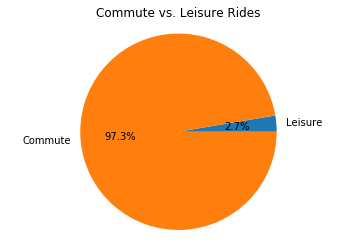

```python
leisure_rides_sum = (bikeshare_data['start_station_name'] == bikeshare_data['end_station_name']).sum() #/ bikeshare_data['start_station_name'].shape[0]
commute_rides_sum = bikeshare_data['start_station_name'].shape[0] - leisure_rides_sum
arr = [leisure_rides_sum, commute_rides_sum]
# commute_rides_prop = 1 - leisure_rides_prop
plt.pie(arr, autopct='%1.1f%%', startangle=0, labels=('Leisure', 'Commute'))
plt.title("Commute vs. Leisure Rides")
plt.axis('equal');
```

## Gender and User Type

The plot below is an adapted bar chart measuring the frequency of each gender and the average number of customers of subscribers of each gender. There appear to be much more male subscribers than any other area. For each gender, the number of customers is a mere fraction compared to the number of subscribers present.

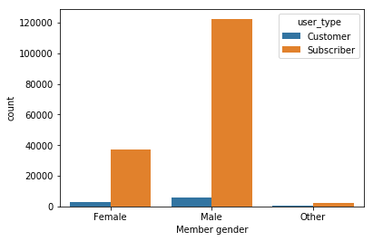

```python
sb.countplot(data=bikeshare_data, x='member_gender', hue='user_type')
plt.xlabel("Member gender");
```

## Ride Distance vs Duration

This scatterplot with a color-encoded variable for the user type shows that there is a correlation present with the riding distance compared with the amount of time spent on the bike. A cube-root scale transformation applied to this plot helps show the data increasing in a more linear fashion.

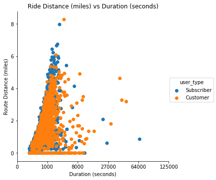

```python
sample_data = bikeshare_data.sample(5000)
trans_data_copy = sample_data.copy()
temp_trans_duration = trans_data_copy['duration_sec'].apply(cbrt_trans)
trans_data_copy['duration_sec'] = temp_trans_duration
g = sb.FacetGrid(data=trans_data_copy, hue='user_type', size=5)
g.map(plt.scatter, 'duration_sec', 'route_distance')
tick_locs = np.arange(0, trans_data_copy['duration_sec'].max()+10, 10)
plt.xticks(tick_locs, cbrt_trans(tick_locs, inverse=True).astype(int))
plt.xlabel("Duration (seconds)")
plt.ylabel("Route Distance (miles)")
plt.title("Ride Distance (miles) vs Duration (seconds)")
g.add_legend();
```